# FigureYa73batchCorrelation

## 7 计算相关系数 Calculate the correlation coefficient

此处采用两种方法计算相关系数：pearson和spearman

Two methods are used here to calculate the correlation coefficient: pearson and spearman

```r
# 获取目标基因的表达数据 / Extract expression data of target gene
# 从表达矩阵中提取目标基因(symbol)的表达值 / Get expression values of target gene from expression matrix
target.exps <- tcga_expr[symbol,]

# 获取其他基因的表达数据 / Extract expression data of other genes
# 从表达矩阵中移除目标基因所在行 / Remove target gene row from expression matrix
other.expr <- tcga_expr[-which(rownames(tcga_expr)==symbol),]

# 计算Pearson相关系数 / Calculate Pearson correlation
# 转置矩阵后计算各基因与目标基因的相关性 / Transpose matrix and calculate correlation with target gene
sgcor <- as.data.frame(cor(t(other.expr), t(target.exps))) #默认pearson / Default is Pearson
colnames(sgcor) <- "r_pearson"  # 重命名列 / Rename column

# 计算Pearson相关系数的p值（耗时操作） / Calculate p-values for Pearson correlation (time-consuming)
sgcor$pval_pearson <- apply(other.expr, 1, function(x) (cor.test(x, t(target.exps))$p.value))


# 计算Spearman相关系数 / Calculate Spearman correlation
sgcor_spearman <- as.data.frame(cor(t(other.expr), t(target.exps), method = "spearman"))
colnames(sgcor_spearman) <- "r_spearman"  # 重命名列 / Rename column
sgcor_spearman$pval_spearman <- apply(other.expr, 1, function(x)(cor.test(x, t(target.exps), method = "spearman")$p.value))

# 合并两种相关系数结果 / Combine both correlation results
cors <- cbind(sgcor, sgcor_spearman)
cors$gene <- rownames(other.expr)  # 添加基因名列 / Add gene name column
head(cors)  # 查看前几行结果 / Preview results
```

```
##          r_pearson pval_pearson    r_spearman pval_spearman   gene
## TMSB10  0.09867739  0.012231174  0.1383104698  0.0004314835 TMSB10
## ACTB   -0.05030063  0.202375044  0.0003180122  0.9935734543   ACTB
## FTL     0.06542165  0.097162665  0.0138442443  0.7258420838    FTL
## S100A6  0.10674522  0.006700422  0.1200420713  0.0022773974 S100A6
## RPS18  -0.02431332  0.537963688 -0.0290373720  0.4619684144  RPS18
## LCN2    0.01620266  0.681508532  0.1145477462  0.0036046425   LCN2
```

```r
# 筛选有效结果（去除NA值） / Filter valid results (remove NAs)
newcor <- cors[!(is.na(cors$r_pearson)),]
dim(newcor)  # 查看剩余基因数量 / Check remaining gene count
```

```
## [1] 999   5
```

```r
# 按Pearson相关系数排序 / Sort by Pearson correlation coefficient
sortcor <- newcor[order(newcor$r_pearson, newcor$r_spearman, decreasing = T),]

# 提取Top相关基因 / Extract top correlated genes
# 获取正相关Top6和负相关Top6 / Get top 6 positive and negative correlated genes
topcor <- sortcor[c(1:topnumber, #正相关Top 6 / Top 6 positive
                   (nrow(sortcor) - topnumber + 1):nrow(sortcor)),] #负相关Top 6 / Top 6 negative
rownames(topcor)  # 显示Top基因名 / Show top gene names
```

```
##  [1] "EIF3I"   "PRDX1"   "KHDRBS1" "UQCRH"   "HMGN2"   "MAGOH"   "SPARC"
##  [8] "SRGN"    "COL6A2"  "TYROBP"  "LGALS1"  "IGFBP7"
```

```r
# 准备可视化数据 / Prepare visualization data
genes <- c(symbol,rownames(topcor))  # 合并目标基因和Top相关基因 / Combine target and top genes
genesexps <- as.data.frame(t(tcga_expr[genes,]))  # 转置表达矩阵 / Transpose expression matrix
sortgenesexps <- genesexps[order(genesexps[,1]),]  # 按目标基因表达量排序 / Sort by target gene expression
samplenum <- nrow(sortgenesexps)  # 获取样本数量 / Get sample count
```

例文中输入数据是ChIP-seq的peak，直接画甚至会有上万个点，因此，作者取了bin。

你也可以不取bin，而是画出所有的点，在参数设置里pointnumber设为NULL

The input data in the example is the peak of ChIP-seq, directly drawing even there will be tens of thousands of points, therefore, the author took bin.

Instead of taking bin, you can also draw all the points, and set pointnumber to NULL in the parameter settings.

```r
# 设置绘图点数 / Set number of points for plotting
# 如果未指定pointnumber，则使用所有样本 / If pointnumber is NULL, use all samples
if(is.null(pointnumber)){
  pointnumber = samplenum
}

# 将样本分组为等大小的区间 / Group samples into equally sized bins
# 创建分组因子变量 / Create grouping factor variable
group <- as.integer(cut(1:samplenum,
                       breaks = c(seq(from = 0.5, to = samplenum,
                                     by = samplenum/pointnumber),
                                 samplenum + 0.5)))

# 初始化数据框用于存储结果 / Initialize dataframe for storing results
ddf <- data.frame(row.names = 1:pointnumber)

# 计算每个基因在每个区间的中位数表达值 / Calculate median expression for each gene in each bin
for(i in 1:(1 + topnumber*2)){  # 遍历目标基因和所有top基因 / Loop through target and top genes
  ddf <- cbind(ddf, tapply(sortgenesexps[,i], group, median))
}

# 设置列名 / Set column names
colnames(ddf) <- c(symbol, topcor$gene)

# 转换数据为长格式便于ggplot绘图 / Melt data to long format for ggplot
mddf <- melt(ddf, id.vars = symbol)

# 添加相关系数和p值信息 / Add correlation coefficients and p-values
# 使用Pearson相关结果 / Using Pearson correlation results
# 如需Spearman结果，可替换为r_spearman和pval_spearman / For Spearman, replace with r_spearman and pval_spearman
mddf$r <- topcor[mddf$variable, ]$r_pearson
mddf$P <- topcor[mddf$variable, ]$pval_pearson
```

## 8 开始画图 Start drawing

### 8.1 一次画一个基因 One gene at a time

以EIF3I为例

Take EIF3I for example.

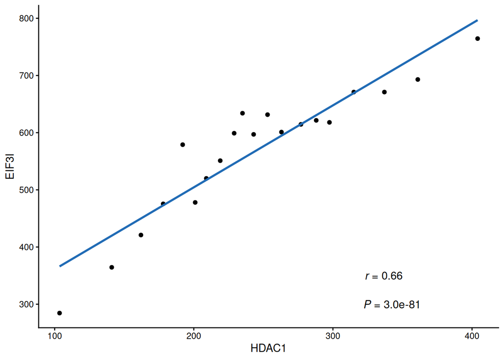

```r
# 选择特定基因的数据 / Select data for specific gene
friend <- "EIF3I"  # 设置要分析的基因 / Set gene to analyze
df <- mddf[mddf$variable == friend,]  # 筛选该基因的数据 / Filter data for this gene

# 格式化相关系数r的显示 / Format correlation coefficient r display
# 创建斜体r值和数值的表达式 / Create expression with italic r and value
rvalue <- as.character(as.expression(substitute(~~italic(r)~"="~rvalue, list(rvalue = format(round(unique(df$r),2), nsmall= 2)))))

# 格式化p值的显示 / Format p-value display
# 创建斜体P值和科学计数法数值的表达式 / Create expression with italic P and scientific notation
pvalue <- as.character(as.expression(substitute(~~italic(P)~"="~pvalue, list(pvalue = format(sprintf("%1.1e", unique(df$P)), nsmall= 2)))))

# 绘制散点图 / Create scatter plot
ggplot(df, aes_string(x = symbol, y = "value")) +
  geom_point() +  # 添加散点 / Add points
  ylab(friend) +  # 设置y轴标签为基因名 / Set y-axis label as gene name
  theme_classic() +  # 使用经典主题 / Use classic theme

  # 添加统计注释 / Add statistical annotations
  # 需要根据数据范围调整x,y坐标位置 / Need to adjust x,y positions based on data range
  annotate("text", x = 334, y = 350, label = rvalue, parse = TRUE) +  # 添加r值 / Add r value
  annotate("text", x = 340, y = 300, label = pvalue, parse = TRUE) +  # 添加p值 / Add p value

  # 添加线性回归线 / Add linear regression line
  geom_smooth(method = "lm", se = FALSE, colour = "#206BB5")  # 蓝色回归线 / Blue regression line
```

```r
# 保存图形 / Save plot
ggsave(paste0(symbol, "_", friend, ".pdf"))  # 输出PDF文件 / Output PDF file
```

### 8.2 批量画图 Batch drawing

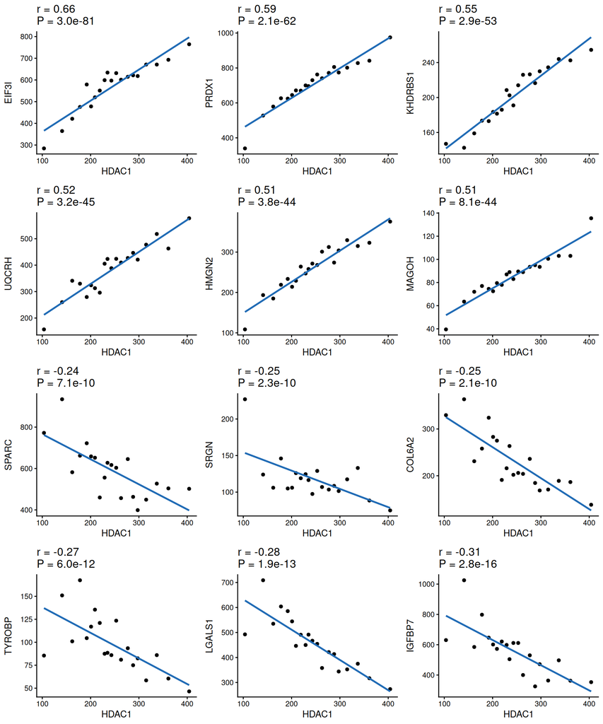

```r
# 使用dlply按基因拆分数据并创建多个ggplot对象
# Split data by gene using dlply and create multiple ggplot objects
# 对mddf数据框按variable(基因名)分组，为每个基因创建一个散点图
# Group mddf dataframe by variable (gene name), create scatter plot for each gene
plist <- dlply(mddf, .(variable), function(trig) {
  ggplot(trig, aes_string(x = symbol, y = "value")) +
    geom_point() +  # 添加散点 / Add scatter points
    ylab(unique(trig$variable)) +  # 设置y轴标签为当前基因名 / Set y-axis label to current gene name
    theme_classic() +  # 使用简洁的经典主题 / Use clean classic theme

    # 添加标题显示相关系数和p值
    # Add title showing correlation coefficient and p-value
    ggtitle(paste0("r = ", round(unique(trig$r), 2),  # 显示r值并保留2位小数 / Show r rounded to 2 decimal places
            "\nP = ", sprintf("%1.1e", unique(trig$P)))) +  # 显示科学计数法p值 / Show p-value in scientific notation

    # 添加线性回归线(蓝色，无置信区间)
    # Add linear regression line (blue, no confidence interval)
    geom_smooth(method = "lm", se = FALSE, colour = "#206BB5")
})

# 使用cowplot包的plot_grid将所有图形排列成网格
# Arrange all plots into grid using plot_grid from cowplot package
pg <- plot_grid(
  plotlist = plist,  # 图形列表 / List of plots
  ncol = 3,  # 每行3个图 / 3 plots per row
  align = "hv"  # 水平和垂直对齐 / Align horizontally and vertically
)
# 显示组合后的图形
# Display combined plot
pg
```

```r
# 保存图形为PDF文件
# Save plot as PDF file
filename <- paste0(symbol, "_cor.pdf")  # 生成文件名(如"HDAC1_cor.pdf") / Generate filename (e.g., "HDAC1_cor.pdf")
ggsave(
  filename,
  width = 8,  # 宽度8英寸 / Width 8 inches
  height = 10  # 高度10英寸 / Height 10 inches
)
```